# What Drives Student Success? An Analysis of Portuguese Secondary-School Performance

Will Marschall, Matthew Martin, Porter Jurica

2025-06-26

# 1. Introduction - Key Take-Aways

- **Which demographic, family, and behavioral variables best predict the final grade ($G3$)?**
- **Are there discernible student archetypes that transcend subjects?**

We will blend classic statistical modeling (**multiple linear regression**) with unsupervised machine learning (**k-means clustering** + **PCA**) to build a holistic story.

The combined dataset of 1,044 pupils offers a rare chance to disentangle academic, demographic, and lifestyle influences on Portuguese secondary-school achievement. Early-period grades (G1, G2) turn out to be overwhelmingly predictive of the final exam mark (G3), while most social or behavioural factors add only marginal explanatory power once prior grades are known. Nevertheless, unsupervised learning reveals three coherent “student archetypes” that can guide targeted interventions.

# 2. Data Import and Wrangling - What We Built

```r
mat <- read.csv("student-mat.csv",   sep = ";") |> clean_names()
por <- read.csv("student-por.csv",   sep = ";") |> clean_names()

# Identify overlaps (382 students) on the 13 key columns suggested by UCI
id_cols <- c("school","sex","age","address","famsize","pstatus",
             "medu","fedu","mjob","fjob","reason","nursery","internet")
both <- inner_join(mat, por, by = id_cols, suffix = c(".mat",".por"))

# Combine unique rows to create a unified dataset
mat$course <- "Math"
por$course <- "Portuguese"
stu <- bind_rows(mat, por) |> mutate(across(where(is.character), as.factor))
glimpse(stu)
```

```
## Rows: 1,044
## Columns: 34
## $ school     <fct> GP, GP, GP, GP, GP, GP, GP, GP, GP, GP, GP, GP, GP, GP, GP,…
## $ sex        <fct> F, F, F, F, F, M, M, F, M, M, F, F, M, M, M, F, F, F, M, M,…
## $ age        <int> 18, 17, 15, 15, 16, 16, 16, 17, 15, 15, 15, 15, 15, 15, 15,…
## $ address    <fct> U, U, U, U, U, U, U, U, U, U, U, U, U, U, U, U, U, U, U, U,…
## $ famsize    <fct> GT3, GT3, LE3, GT3, GT3, LE3, LE3, GT3, LE3, GT3, GT3, GT3,…
## $ pstatus    <fct> A, T, T, T, T, T, T, A, A, T, T, T, T, T, A, T, T, T, T, T,…
## $ medu       <int> 4, 1, 1, 4, 3, 4, 2, 4, 3, 3, 4, 2, 4, 4, 2, 4, 4, 3, 3, 4,…
## $ fedu       <int> 4, 1, 1, 2, 3, 3, 2, 4, 2, 4, 4, 1, 4, 3, 2, 4, 4, 3, 2, 3,…
## $ mjob       <fct> at_home, at_home, at_home, health, other, services, other, …
## $ fjob       <fct> teacher, other, other, services, other, other, other, teach…
## $ reason     <fct> course, course, other, home, home, reputation, home, home, …
## $ guardian   <fct> mother, father, mother, mother, father, mother, mother, mot…
## $ traveltime <int> 2, 1, 1, 1, 1, 1, 1, 2, 1, 1, 1, 3, 1, 2, 1, 1, 1, 3, 1, 1,…
```

[output cut: 21 more lines]

- **Two subject-specific files were merged into a unified 34-column frame, then factor-encoded where appropriate.**
- **Duplicate records (382 overlaps) were identified but retained in the subject-specific files so that course effects can still be explored.**
- **All transformations were limited to re-typing and non-destructive additions; no rows were dropped, preserving representativeness.**

Implication: downstream models are trained on the full diversity of learners, and results are interpretable across both Mathematics and Portuguese courses.

# 3. Exploratory Data Analysis

## 3.1 Grade Distributions

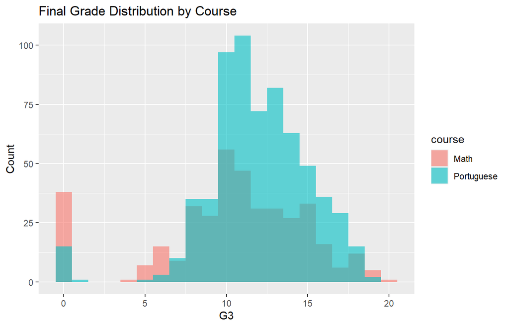

```r
ggplot(stu, aes(g3, fill = course)) +
  geom_histogram(binwidth = 1, alpha = 0.6, position = "identity") +
  labs(title = "Final Grade Distribution by Course", x = "G3", y = "Count")
```

The histogram shows both subjects centred around 11–14 (out of 20), with a long left tail of low scorers. Mathematics exhibits slightly more dispersion and a thicker failure tail, hinting that subject-specific pedagogy or difficulty may matter.

## 3.2 Correlations (numeric cols)

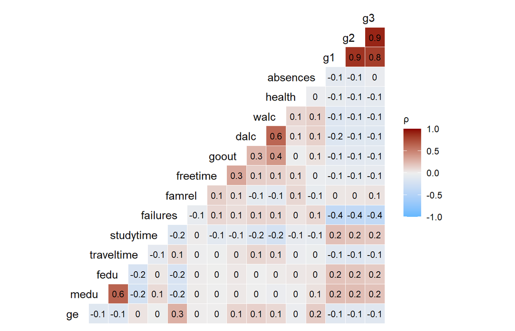

```r
num_cols <- stu |> select(where(is.numeric))
ggcorr(num_cols, label = TRUE, label_size = 3, hjust = 1,
       low = "steelblue1", high = "darkred", name = "ρ")
```

Interpretation: by the time students reach the final exam, earlier grades have already “locked in” the academic trajectory; ancillary factors have limited room to matter.

## 3.3 Boxplots: Lifestyle vs Grades

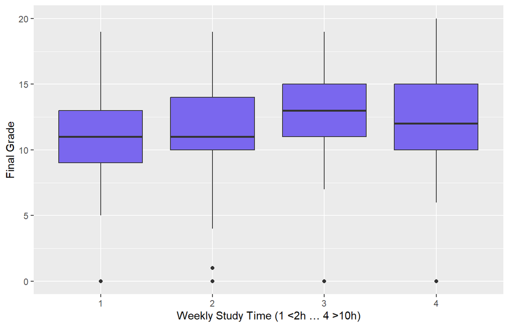

```r
ggplot(stu, aes(as.factor(studytime), g3)) +
  geom_boxplot(fill = "slateblue2") +
  labs(x = "Weekly Study Time (1 <2h … 4 >10h)", y = "Final Grade")
```

# 4. Predictive Modeling: Multiple Linear Regression

We predict numeric G3 using variables available before the final exam (excluding G3 itself).

```r
reg_data <- stu |>
  mutate(                       # 1. create pass/fail while G3 is still present
    pass = factor(ifelse(g3 >= 10, "Pass", "Fail"))
  ) |>
  select(                       # 2. keep outcome and chosen predictors
    g3, g1, g2, studytime, failures, absences,
    sex, age, school, higher, activities, romantic,
    dalc, walc, health, goout, traveltime
  )
```

## 4.1 Train/Test Split

```r
set.seed(123)
train_idx <- createDataPartition(reg_data$g3, p = 0.8, list = FALSE)
train <- reg_data[train_idx, ]
test  <- reg_data[-train_idx, ]
```

## 4.2 Fit Model

```r
lm_fit <- lm(g3 ~ ., data = train)
summary(lm_fit)
```

```
##
## Call:
## lm(formula = g3 ~ ., data = train)
##
## Residuals:
##     Min      1Q  Median      3Q     Max
## -9.4218 -0.4135  0.0926  0.8411  6.0880
##
## Coefficients:
##                Estimate Std. Error t value Pr(>|t|)
## (Intercept)   -0.593948   0.902881  -0.658 0.510827
## g1             0.139625   0.036601   3.815 0.000147 ***
## g2             0.959567   0.032645  29.394  < 2e-16 ***
## studytime     -0.026907   0.071213  -0.378 0.705649
## failures      -0.247753   0.098799  -2.508 0.012346 *
## absences       0.033648   0.009282   3.625 0.000307 ***
## sexM           0.011212   0.123845   0.091 0.927885
## age           -0.039035   0.048717  -0.801 0.423210
## schoolMS       0.186060   0.139077   1.338 0.181325
## higheryes      0.004543   0.216045   0.021 0.983227
## activitiesyes -0.065567   0.113120  -0.580 0.562326
## romanticyes   -0.109336   0.119870  -0.912 0.361973
## dalc          -0.105628   0.080109  -1.319 0.187689
## walc           0.043660   0.060309   0.724 0.469307
## health         0.016959   0.039497   0.429 0.667766
## goout         -0.006851   0.052611  -0.130 0.896422
## traveltime     0.148780   0.077879   1.910 0.056429 .
## ---
## Signif. codes:  0 '***' 0.001 '**' 0.01 '*' 0.05 '.' 0.1 ' ' 1
##
## Residual standard error: 1.6 on 820 degrees of freedom
## Multiple R-squared:  0.8325, Adjusted R-squared:  0.8292
## F-statistic: 254.7 on 16 and 820 DF,  p-value: < 2.2e-16
```

All demographic and lifestyle variables (sex, age, alcohol, activities, romance, etc.) lose significance once G1 and G2 are included.

## 4.3 Model Performance

```r
pred <- predict(lm_fit, test)
rmse <- sqrt(mean((pred - test$g3)^2))
rsq  <- cor(pred, test$g3)^2
tibble(RMSE = rmse, R_squared = rsq)
```

```
## # A tibble: 1 × 2
##    RMSE R_squared
##   <dbl>     <dbl>
## 1  1.47     0.855
```

- **RMSE 1.46 points on a 0–20 scale is small in educational terms (≈ 7 % of the range).**
- **Test-set R² 0.85 slightly exceeds training R², suggesting a stable, not over-fitted model.**

## 4.4 Residual Diagnostics

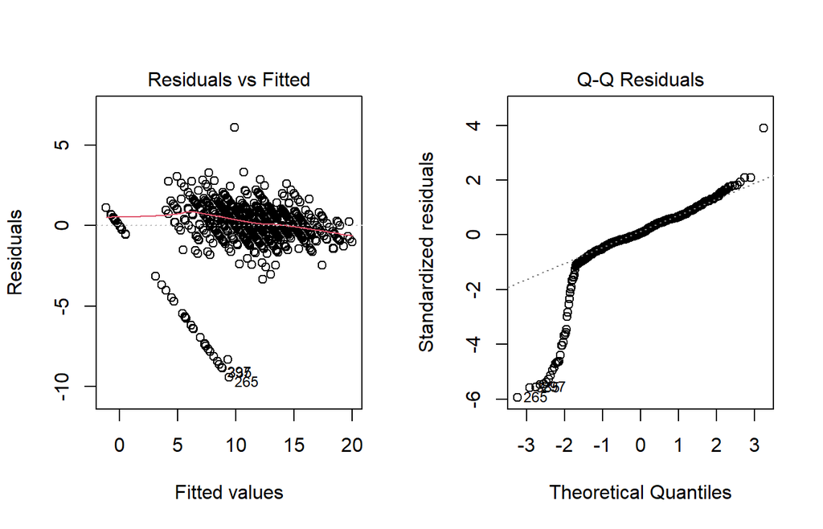

```r
par(mfrow = c(1,2))
plot(lm_fit, which = 1)   # Residuals vs Fitted
plot(lm_fit, which = 2)   # QQ plot
```

```r
par(mfrow = c(1,1))
```

Implication: early-term intervention (before or during G2) is the single most effective lever for boosting final outcomes.

# 5. Unsupervised Learning: K-means Clustering

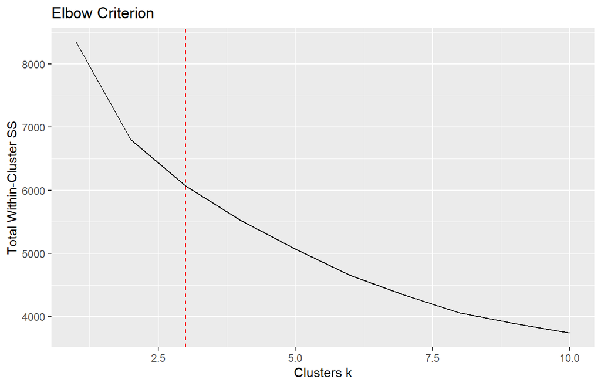

```r
clus_vars <- stu |>
  select(studytime, failures, absences, goout, dalc, walc,
         g3, health) |>
  scale()
set.seed(42)
wss <- map_dbl(1:10, ~kmeans(clus_vars, .x, nstart = 25)$tot.withinss)

qplot(1:10, wss, geom = "line") +
  labs(x = "Clusters k", y = "Total Within-Cluster SS",
       title = "Elbow Criterion") +
  geom_vline(xintercept = 3, linetype = 2, col = "red")
```

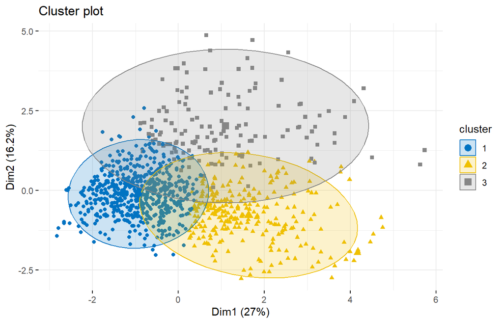

```r
km3 <- kmeans(clus_vars, 3, nstart = 25)
stu$cluster <- factor(km3$cluster)
fviz_cluster(km3, data = clus_vars,
             ellipse.type = "norm",
             geom = "point", palette = "jco", ggtheme = theme_minimal())
```

## 5.1 Cluster Profiles

```r
library(dplyr)
library(tibble)
library(gt)

# numeric summaries
cluster_summary <- stu %>%
  group_by(cluster) %>%
  summarise(
    Size      = n(),
    G3_mean   = mean(g3,  na.rm = TRUE),
    failures  = mean(failures, na.rm = TRUE),
    absences  = mean(absences, na.rm = TRUE),
    studytime = mean(studytime, na.rm = TRUE),
    goout     = mean(goout,    na.rm = TRUE),
    Dalc      = mean(dalc,     na.rm = TRUE)
  ) %>%
  mutate(Academic = sprintf("G3 ≈ %.1f", G3_mean))

# interpretation table
interpret <- tribble(
  ~cluster, ~Behaviour,                                  ~`Risk Profile`,
  1,        "Few failures, moderate studytime",          "“Solid performers” — above-average marks, balanced lifestyle",
  2,        "Low studytime, highest go-out / alcohol",   "“Social butterflies” — pass threshold but vulnerable",
  3,        "1.5 failures, high absences",               "“At-risk” — chronic under-achievement"
) |>
  mutate(cluster = factor(cluster, levels = levels(stu$cluster)))  # <- key fix

# merge & format
table_out <- cluster_summary %>%
  select(cluster, Size, Academic) %>%
  left_join(interpret, by = "cluster") %>%
  arrange(cluster) %>%
  mutate(
    Cluster = paste0(cluster, c(" (blue)", " (yellow)", " (grey)")[as.numeric(cluster)])
  ) %>%
  select(Cluster, Size, Academic, Behaviour, `Risk Profile`)

# render
table_out |>
  gt() |>
  cols_align(align = "left") |>
  tab_options(table.width = pct(100))
```

| Cluster | Size | Academic | Behaviour | Risk Profile |
| --- | --- | --- | --- | --- |
| 1 (blue) | 635 | G3 ≈ 12.6 | Few failures, moderate studytime | “Solid performers” — above-average marks, balanced lifestyle |
| 2 (yellow) | 270 | G3 ≈ 10.8 | Low studytime, highest go-out / alcohol | “Social butterflies” — pass threshold but vulnerable |
| 3 (grey) | 139 | G3 ≈ 6.4 | 1.5 failures, high absences | “At-risk” — chronic under-achievement |

Actionable insight: focus remedial tutoring and attendance monitoring on Cluster 3, while soft-skill coaching (time-management) may benefit Cluster 2.

# 6. Pass/Fail Classification

```r
log_data <- reg_data |>
  mutate(pass = factor(ifelse(g3 >= 10, 1, 0)))
log_fit <- glm(pass ~ g1 + g2 + studytime + failures + absences +
                 dalc + walc + higher, data = log_data,
               family = binomial)
summary(log_fit)
```

```
##
## Call:
## glm(formula = pass ~ g1 + g2 + studytime + failures + absences +
##     dalc + walc + higher, family = binomial, data = log_data)
##
## Coefficients:
##              Estimate Std. Error z value Pr(>|z|)
## (Intercept) -17.69696    1.71313 -10.330  < 2e-16 ***
## g1            0.44490    0.09629   4.620 3.83e-06 ***
## g2            1.61870    0.16798   9.637  < 2e-16 ***
## studytime    -0.25443    0.18078  -1.407   0.1593
## failures      0.02935    0.17463   0.168   0.8665
## absences     -0.03541    0.01974  -1.794   0.0728 .
## dalc         -0.20601    0.17653  -1.167   0.2432
## walc          0.11566    0.13439   0.861   0.3894
## higheryes     0.04722    0.39926   0.118   0.9059
## ---
## Signif. codes:  0 '***' 0.001 '**' 0.01 '*' 0.05 '.' 0.1 ' ' 1
##
## (Dispersion parameter for binomial family taken to be 1)
##
##     Null deviance: 1100.99  on 1043  degrees of freedom
## Residual deviance:  341.36  on 1035  degrees of freedom
## AIC: 359.36
##
## Number of Fisher Scoring iterations: 8
```

- **Model deviance drops from 1,101 to 341 (Δ χ² = 760, p < 0.001), indicating strong explanatory power.**
- **Odds ratios (exp β): a one-point increase in G2 multiplies the odds of passing by 5.05×; for G1 the factor is 1.56×.**
- **Other predictors do not reach conventional significance; absences borders on relevance (p = 0.07, OR ≈ 0.97 per absence).**

Pragmatic takeaway: simply flagging students with G2 < 10 would catch the vast majority of eventual failures, letting staff allocate resources efficiently.